# Programowanie w R - podstawy

Magda G.

12 sierpnia 2018

## Poziom 0

### Podstawowe operacje arytmetyczne:

Z **R** można korzystać jak z kalkulatora. Wpisujemy bezpośrednio do konsoli:

```r
# Dodawanie
3 + 7
```

```
[1] 10
```

```r
# Odejmowanie
7 - 3
```

```
[1] 4
```

```r
# Mnożenie
3 * 7
```

```
[1] 21
```

```r
# Dzielenie
7/3
```

```
[1] 2.333333
```

```r
# Podnoszenie do kwadratu
2^3
```

```
[1] 8
```

```r
# Modulo - zwraca resztę z dzielenia
8 %% 3
```

```
[1] 2
```

### Podstawowe funkcje matematyczne:

#### Logarytmy i potęgowanie

```r
x=10
log2(x) # logarithms o podstawie 2 z x
```

```
[1] 3.321928
```

```r
log10(x) # logaritms o podstawie 10 z x
```

```
[1] 1
```

```r
exp(x) # eksponenta z x
```

```
[1] 22026.47
```

#### Funkcje trygonometryczne

```r
cos(x) # cosinus z x
```

```
[1] -0.8390715
```

```r
sin(x) # sinus z x
```

```
[1] -0.5440211
```

```r
tan(x) # tangens z x
```

```
[1] 0.6483608
```

```r
acos(x) # arc-cosinus z x
```

```
[1] NaN
```

```r
asin(x) # arc-sinus z x
```

```
[1] NaN
```

```r
atan(x) #arc-tangens z x
```

```
[1] 1.471128
```

#### Inne funkcje matematyczne

```r
abs(x) # wartość bezwzgledna z x
```

```
[1] 10
```

```r
sqrt(x) # pierwiastek kwadratowy z x
```

```
[1] 3.162278
```

### Przypisywanie wartości do zmiennych

Zmienne służą do przechowywania wartości

Przykład: cena jabłek w złotówkach przypisana do zmiennej “cena_jablek”

```r
cena_jablek <- 2 # Cena jabłek = 2 zł

cena_jablek = 2 # lub inny zapis
```

```
R jest wrażliwy na wielkość liter cena_jablek, to nie to samo, co Cena_jablek
```

```r
cena_jablek # wpisanie nazwy zmiennej wypisuje jej wartość
```

```
[1] 2
```

```r
print(cena_jablek) # działa tak samo
```

```
[1] 2
```

Na utworzonej zmiennej można wykonywać działania

```r
5 * cena_jablek # pomnożyć cenę jabłek przez 5
```

```
[1] 10
```

```r
cena_jablek <- 5 # zmienić wartość zmiennej
cena_jablek
```

```
[1] 5
```

#### Tworzenie 2 zmiennych i wykonywanie obliczeń

```r
# Wysokość prostokąta
wys <- 10
# Szerokość prostokąta
szer <- 5
# liczenie powierzchni prostokąta
pow <- wys*szer
print(pow)
```

```
[1] 50
```

Funkcja **ls()** wyświetla listę zmiennych, które utworzyliśmy. W RStudio wszystkie zmienne wyświetlane sa w panelu *“Environment”*.

```r
ls()
```

```
[1] "cena_jablek" "pow"         "szer"        "wys"         "x"
```

```
Kolekcja utworzonnych zmiennych nosi nazwę **Workspace**.
Każda zmienna zajmuje pamięć komputera. Przy pracy z dużą ilością danych
warto jest usuwać zbędne zmienne.
```

```r
rm(wys, szer) # usuwanie zmiennych znajdujących się w nawiasie
ls()
```

```
[1] "cena_jablek" "pow"         "x"
```

## Poziom 1

### Podstawowe typy danych

Dane dzielimy na: liczbowe, tekstowe i logiczne

```r
# Dana liczbowa: Ile masz lat?
wiek <- 28
# Obiekt tekstowy: Jak masz na imię?
imie <- "Bartek"
# Obiekt logiczny: Jesteś naukowcem?
# (yes/no) <=> (TRUE/FALSE)
naukowiec <- TRUE
```

Wektor tekstowy tworzymy wykorzystując ("") lub (’’). Jeśli w tekście zmiennej znajduje się cudzysłów lub apostrof, należy zastsować znak ucieczki () lub w pzrypadku pojawienia się apostofu zdanie objąć cudzysłowem i odwrotnie

```r
'My friend\'s name is "George"'
```

```
[1] "My friend's name is \"George\""
```

```r
"My friend's name is \"George\""
```

```
[1] "My friend's name is \"George\""
```

Możemy sprawdzić typ wybranej zmiennej

```r
class(wiek)
```

```
[1] "numeric"
```

```r
class(imie)
```

```
[1] "character"
```

Stosując funkcje: **is.numeric()**, **is.character()**, **is.logical()** sprawdzamy czy zmienna ma konkretny typ:

```r
is.numeric(wiek)
```

```
[1] TRUE
```

```r
is.numeric(imie)
```

```
[1] FALSE
```

Możliwe jest zmienianie typu zmiennej

```r
wiek
```

```
[1] 28
```

```r
as.character(wiek) # zmienia daną liczbową na tekstową.
```

```
[1] "28"
```

```r
as.numeric(wiek) # Odwrotna zmiana
```

```
[1] 28
```

### Wektory (Vector)

Wektor to kombinacja wielu zmiennych liczbowych, tekstowych lub logicznych. Tworzymy wektroy liczbowe, tekstowe i logiczne. Wektor może zawierać tylko jeden typ danych. Wektor tworzony jest przy użyciu funkcji **c()**

```r
# Wiek przyjaciół w postaci wektora liczbowego
wiek_przyj <- c(27, 25, 29, 26)
wiek_przyj
```

```
[1] 27 25 29 26
```

```r
# Imiona przyjaciół jako wektor tekstowy
przyj <- c("Marta", "Ala", "Janek", "Piotr")
przyj
```

```
[1] "Marta" "Ala"   "Janek" "Piotr"
```

```r
# Stan cywilny przyjaciół jako wektor logiczny
# Czy jest żonaty/ zamężna? (yes/no <=> TRUE/FALSE)
zajety <- c(TRUE, FALSE, TRUE, TRUE)
zajety
```

```
[1]  TRUE FALSE  TRUE  TRUE
```

Możlie jest nadawanie wartościom wektora etykiet, które mogą służyć do selekcjonowania odpowiednich danych. Służy do tego funkcja **names()**

```r
# Wektor bez etykiet
wiek_przyj
```

```
[1] 27 25 29 26
```

```r
# Przypisywanie etykiet
names(wiek_przyj) <- c("Marta", "Ala", "Janek", "Piotr")
wiek_przyj
```

```
Marta   Ala Janek Piotr
   27    25    29    26
```

```r
# Tworzenie wektora z etykietami
wiek_przyj <- c(Marta = 27, Ala = 25, Janek = 29, Piotr = 26)
wiek_przyj
```

```
Marta   Ala Janek Piotr
   27    25    29    26
```

Każdy wektor ma określona długość. Do jej określania służy funkcja **length()**

```r
# Liczba przyjaciół
length(przyj)
```

```
[1] 4
```

#### Brakujące wartości

Brakujące wartości zapisywane są jako NA

```r
# NA - nie ma informacji dotyczącej dzieci
dzieci <- c(Marta = "yes", Ala = "yes", Janek = NA, Piotr = NA)
dzieci
```

```
Marta   Ala Janek Piotr
"yes" "yes"    NA    NA
```

```r
is.na(dzieci) # sprawdza czy wektor zawiera brakujące dane
```

```
Marta   Ala Janek Piotr
FALSE FALSE  TRUE  TRUE
```

```
Występuje też inny rodzaj brakującej wartości NaN, pojawiającej się
w wyniku nieprawidłowej kalkulacji np. 0/0 = NaN. Funkcja is.na() obie te zmienne
traktuje identycznie.
```

#### Wybieranie danych z wektorów

Selekcjonowanie danych

```r
# Wybieramy przyjaciela nr 2
przyj[2] # indeksowanie przy użyciu []
```

```
[1] "Ala"
```

```r
# Wybieramy przyjaciela nr 2 i 4
przyj[c(2, 4)]
```

```
[1] "Ala"   "Piotr"
```

```r
# Wybieramy przyjaciela od 1 do 3
przyj[1:3] # R indeksuje od 1 a nie od 0
```

```
[1] "Marta" "Ala"   "Janek"
```

```r
# Możliwe jest stosowanie etykiet

wiek_przyj["Ala"]
```

```
Ala
 25
```

```r
# Pomijanie danych dzięki stosowaniu indeksowania ujemnego
przyj[-2] # Wybieramy wszystkich poza 2
```

```
[1] "Marta" "Janek" "Piotr"
```

```r
# Pominięcie przyjaciół 2 i 4
przyj[-c(2, 4)]
```

```
[1] "Marta" "Janek"
```

```r
# Pominięcie przyjaciół  od 1 do 3
przyj[-(1:3)]
```

```
[1] "Piotr"
```

```r
# Selekcjonowanie z użyciem wektora logicznego
przyj[zajety == TRUE]
```

```
[1] "Marta" "Janek" "Piotr"
```

```r
# Selekcjonowanie starzszych niż 27 lat
przyj[wiek_przyj >= 27]
```

```
[1] "Marta" "Janek"
```

```r
# Przyjaciele, którzy nie mają 27 lat
przyj[wiek_przyj != 27]
```

```
[1] "Ala"   "Janek" "Piotr"
```

```r
# Pozbywanie się danych brakujących
dzieci
```

```
Marta   Ala Janek Piotr
"yes" "yes"    NA    NA
```

```r
dzieci[!is.na(dzieci)] # Zachowuje dane różne od NA (!is.na())
```

```
Marta   Ala
"yes" "yes"
```

```r
# Zastąpienie NA tekstem "no"
dzieci[is.na(dzieci)] <- "no"
dzieci
```

```
Marta   Ala Janek Piotr
"yes" "yes"  "no"  "no"
```

```
Operatory logiczne w R:

* "<"" : mniej niż
* ">" : więcej niż
* "<="" : mniej lub równe
* ">=" : więcej lub równe
* "==" : równe
* "!=" : nie równe
```

#### Obliczenia na wektorach

```r
# podstawowe operacje arytmetyczne i funkcje mogą być zastosowane w dzialaniach na wektorach numerycznych.
# Operacje wykonywane są na każdym elemencie wektora po kolei.

# Pensja moich przyjaciół w złotych
pensja <- c(2000, 1800, 2500, 3000)
names(pensja) <- c("Marta", "Ala", "Janek", "Piotr") # Przypisanie etykiet
pensja
```

```
Marta   Ala Janek Piotr
 2000  1800  2500  3000
```

```r
# Przemnożenie przez 2
pensja*2
```

```
Marta   Ala Janek Piotr
 4000  3600  5000  6000
```

```r
# Mnożenie przez różne współczynniki
# Utworzenie wektora współczynników o tej samej długości, co wektor pensja
wsp <- c(2, 1.5, 1, 3)
pensja*wsp # Pomnożenie wektorów
```

```
Marta   Ala Janek Piotr
 4000  2700  2500  9000
```

#### Inne użyteczne funkcje

```r
x <- c(4, 16, 9, 11, 33, 7, 15, 80, 46)
max(x) # Zwraca maksimum wektora x
```

```
[1] 80
```

```r
min(x) # Zwraca minimum wektora x
```

```
[1] 4
```

```r
range(x) # Zwraca zakres wektora x
```

```
[1]  4 80
```

```r
length(x) # Zwraca liczbę elementów wektora x
```

```
[1] 9
```

```r
sum(x) # Zwraca sumę elementów wektora x
```

```
[1] 221
```

```r
prod(x) # Zwraca iloczyn elementów wektora x
```

```
[1] 80791603200
```

```r
# Średnią x można policzyć na 2 sposoby
sum(x)/length(x)
```

```
[1] 24.55556
```

```r
mean(x)
```

```
[1] 24.55556
```

```r
sd(x) # Odchylenie standardowe wektora x
```

```
[1] 24.81487
```

```r
var(x) # Wariancja elementów wektora x
```

```
[1] 615.7778
```

```r
sort(x) # Sortowanie wektora x rosnąco
```

```
[1]  4  7  9 11 15 16 33 46 80
```

```r
sort(x, decreasing = TRUE) # Sortowanie wektora x malejąco
```

```
[1] 80 46 33 16 15 11  9  7  4
```

```r
# Korzystajac z wcześniejszych danych możemy policzyć
sum(pensja)
```

```
[1] 9300
```

```r
mean(pensja)
```

```
[1] 2325
```

```r
range(pensja)
```

```
[1] 1800 3000
```

### Macierze (Matrix)

Mcierze przypominają arkusze Excel’a i podobnie jak one składają się z wielu rzędów i kolumn. Składają się z wielu pojedynczych wektorów **jednego typu**. Wykorzystywane są do przechowywania danych tabelarycznych - zwykle pojedynczy rząd to osobnik/ obserwacja, a kolumna, to zmienna.

Do tworzenia macierzy wykorzystuje sie funkcję `cbind()` lub `rbind()` w następujący sposób:

```r
# Wektory liczbowe
col1 <- c(5, 6, 7, 8, 9)
col2 <- c(2, 4, 5, 9, 8)
col3 <- c(7, 3, 4, 8, 7)

# Połączenie wektorów kolumnami
tab1 <- cbind(col1, col2, col3)
tab1
```

```
     col1 col2 col3
[1,]    5    2    7
[2,]    6    4    3
[3,]    7    5    4
[4,]    8    9    8
[5,]    9    8    7
```

```r
# Zmiana nazw rzędów
rownames(tab1) <- c("row1", "row2", "row3", "row4", "row5")
tab1
```

```
     col1 col2 col3
row1    5    2    7
row2    6    4    3
row3    7    5    4
row4    8    9    8
row5    9    8    7
```

```
cbind(): składa obiekty R kolumnami;
rbind(): składa obiekty R rzędami;
rownames(): wypisuje lub ustawia nazwy rzędów macierzy i jej podobnych;
colnames(): wypisuje lub ustawia nazwy kolumn macierzy i jej podobnych
```

Do transponowania macierzy służy funkcja `t()`

```r
t(tab1)
```

```
     row1 row2 row3 row4 row5
col1    5    6    7    8    9
col2    2    4    5    9    8
col3    7    3    4    8    7
```

Możliwe jest utworzenie macierzy z wykorzystaniem funkcji `matrix()`

```r
# matrix(data = NA, nrow = 1, ncol = 1, byrow = FALSE, dimnames = NULL)
  # data: opcjonalny wektor danych
  # nrow, ncol: liczba rzędów i kolumn macierzy
  # byrow: wartość logiczna. Jeśli FALSE (wartość wyjściowa) macierz wypełniana jest kolumnami,
  # w przeciwnym przypadku - rzędami.
  # dimnames: Lista 2 wektorów zawierająca, odpowiednio, nazwy rzędów i nazwy kolumn.

mdat <- matrix(
           data = c(1,2,3, 11,12,13),
           nrow = 2, byrow = TRUE,
           dimnames = list(c("row1", "row2"), c("C.1", "C.2", "C.3"))
           )
mdat
```

```
     C.1 C.2 C.3
row1   1   2   3
row2  11  12  13
```

Wymiary macierzy możemy poznać dzięki następującym funkcjom:

```r
ncol(tab1) # Liczba kolumn
```

```
[1] 3
```

```r
nrow(tab1) # Liczba rzędów
```

```
[1] 5
```

```r
dim(tab1) # Liczba kolumn i rzędów
```

```
[1] 5 3
```

Do wybierania elementów z macierzy `(my_data[row, col])` służą:

##### **1. dodatnie indeksy:**

```r
# Wybierz rząd 2
tab1[2, ]
```

```
col1 col2 col3
   6    4    3
```

```r
# Wybierz rzędy od 2 do 4
tab1[2:4, ]
```

```
     col1 col2 col3
row2    6    4    3
row3    7    5    4
row4    8    9    8
```

```r
# Wybierz kilka rzędów nie tworzących zakresu np.: 2 i 4
tab1[c(2,4), ]
```

```
     col1 col2 col3
row2    6    4    3
row4    8    9    8
```

```r
# Wybierz kolomnę 3
tab1[, 3]
```

```
row1 row2 row3 row4 row5
   7    3    4    8    7
```

```r
# Wybierz wartość znajdującą się w rzędzie 2 i kolummnie 3
tab1[2, 3]
```

```
[1] 3
```

##### **2. nazwy kolumn/ rzędów lub jednocześnie - indeksy i nazwy**

```r
# Wybierz kolumnę 2
tab1[, "col2"]
```

```
row1 row2 row3 row4 row5
   2    4    5    9    8
```

```r
# Wybierz wartość z rzędu 3 i kolumny 2
tab1[3, "col2"]
```

```
[1] 5
```

##### **3. indeksowanie wartościami ujemnymi - wykluczanie niektórych kolumn/ rzędów**

```r
# Usuń kolumnę 1
tab1[, -1]
```

```
     col2 col3
row1    2    7
row2    4    3
row3    5    4
row4    9    8
row5    8    7
```

##### **4. wektory logiczne**

```r
col3 <- tab1[, "col3"]
# Wybieranie kolumny (zmiennej), która będzie podstawą selekcji, tu: col3.
# W col3 wybieramy elementy większe lub równe 4 i zatrzymujemy w macierzy
# jedynie te wiersze, które spełniają ten warunek.
# W kolumnie 3 przeprowadzone zostaje sprawdzenie warunku i R w pamięci
# zapisuje wartości TRUE lub FALSE dla każdego elementu.
# Zatrzymywane są wartości TRUE

tab1[col3 >= 4, ]
```

```
     col1 col2 col3
row1    5    2    7
row3    7    5    4
row4    8    9    8
row5    9    8    7
```

#### Obliczenia na macierzach

Mozliwe jest przeprowadzanie prostych kalkulacji na macierzach

```r
tab1*2 # Mnożenie elementów macierzy
```

```
     col1 col2 col3
row1   10    4   14
row2   12    8    6
row3   14   10    8
row4   16   18   16
row5   18   16   14
```

```r
log2(tab1) # Oblicznaie logarytmu dla każdego elementu macierzy
```

```
         col1     col2     col3
row1 2.321928 1.000000 2.807355
row2 2.584963 2.000000 1.584963
row3 2.807355 2.321928 2.000000
row4 3.000000 3.169925 3.000000
row5 3.169925 3.000000 2.807355
```

```r
rowSums(tab1) # Sumowanie wartości po rzędach
```

```
row1 row2 row3 row4 row5
  14   13   16   25   24
```

```r
colSums(tab1) # Sumowanie wartości po kolumnach
```

```
col1 col2 col3
  35   28   29
```

```r
rowMeans(tab1) # Średnia wartość w każdym rzędzie
```

```
    row1     row2     row3     row4     row5
4.666667 4.333333 5.333333 8.333333 8.000000
```

```r
colMeans(tab1) # Średnia wartość w każdej kolumnie
```

```
col1 col2 col3
 7.0  5.6  5.8
```

#### Kożystanie z funkcji `apply()`

Funkcji tej można użyć w celu wykonania obliczeń (na rzędach i kolumnach macierzy) z wykorzystaniem wbudowanych funkcji

###### **Uproszczona forma funkcji `apply()` jest następująca:**

```
apply(X, MARGIN, FUN),

gdzie:
X - macierz;
MARGIN - możliwe wartości, to 1 dla rzędów lub 2 dla kolumn;
FUN - wybrana funkcja do zastosowania na rzędach/ kolumnach.
```

```r
# Policz średnią rzędów
apply(tab1, 1, mean)
```

```
    row1     row2     row3     row4     row5
4.666667 4.333333 5.333333 8.333333 8.000000
```

```r
# Oblicz/ wyszukaj medianę w rzędach
apply(tab1, 1, median)
```

```
row1 row2 row3 row4 row5
   5    4    5    8    8
```

```r
# Policz średnie kolumn
apply(tab1, 2, mean)
```

```
col1 col2 col3
 7.0  5.6  5.8
```

### Czynniki (Factor)

Zmienne te reprezentują kategorie lub grupy danych. Do tworzenia czynników wykorzystuje się funkcję `factor()`

```r
# Tworzenie
grupa_przyj <- factor(c(1, 2, 1, 2))
grupa_przyj
```

```
[1] 1 2 1 2
Levels: 1 2
```

Zmienna *‘grupa_przyj’* składa się z 2 kategorii: 1 i 2 - poziomu czynnika. Funkcja `levels()` wypisuje te poziomy.

```r
# Jakie są poziomy zmiennej?
levels(grupa_przyj)
```

```
[1] "1" "2"
```

Możliwa jest zmiana nazw poziomów czynnikóW

```r
# Zmiana nazw poziomów zmiennej
levels(grupa_przyj) <- c("przyjaciel", "kolega")
grupa_przyj
```

```
[1] przyjaciel kolega     przyjaciel kolega
Levels: przyjaciel kolega
```

Można wymusić kolejność wyświetlania poziomów czynników

```r
# Zmiana porządku wyświetlania poziomów
grupa_przyj <- factor(grupa_przyj,
                      levels = c("kolega", "przyjaciel"))
grupa_przyj
```

```
[1] przyjaciel kolega     przyjaciel kolega
Levels: kolega przyjaciel
```

```r
summary(grupa_przyj) # Wyświetla liczbę obserwacji należących do każdego poziomu
```

```
    kolega przyjaciel
         2          2
```

Do sprawdzenia czy dana zmienna jest czynnikiem służy funkcja logiczna `is.factor()` a funkcja `as.factor()` służy do zamiany innej zmiennej na czynnik

```r
# Czy 'grupa_przyj' to czynnik?
is.factor(grupa_przyj)
```

```
[1] TRUE
```

```r
# Czy 'zajety' jest czynnikiem?
is.factor(zajety)
```

```
[1] FALSE
```

```r
# Zamienić 'zajety' na czynnik
as.factor(zajety)
```

```
[1] TRUE  FALSE TRUE  TRUE
Levels: FALSE TRUE
```

Do policzenia wartości z podziałem na grupy można wykorzystać czynniki. Funkcja `tapply()` posłuży do użycia funkcji (tu średniej) do obliczeń w grupach.

```r
pensja
```

```
Marta   Ala Janek Piotr
 2000  1800  2500  3000
```

```r
grupa_przyj
```

```
[1] przyjaciel kolega     przyjaciel kolega
Levels: kolega przyjaciel
```

```r
# Średnia pensja w grupach
sred_pens <- tapply(pensja, grupa_przyj, mean)
sred_pens
```

```
    kolega przyjaciel
      2400       2250
```

```r
# Wielkość każdej z grup
tapply(pensja, grupa_przyj, length)
```

```
    kolega przyjaciel
         2          2
```

```r
# Tworzenie tabeli rozdzielczej/ krzyżowej
table(grupa_przyj)
```

```
grupa_przyj
    kolega przyjaciel
         2          2
```

```r
# Badanie zależności pomiędzy zmiennymi
table(grupa_przyj, zajety)
```

```
            zajety
grupa_przyj  FALSE TRUE
  kolega         1    1
  przyjaciel     0    2
```

### Ramki danych (Data Frame)

Ramka danych przypomina macierz, ale może zawierać zmienne różnego typu - kolumny z wartościami numerycznymi, logicznymi i tekstowymi. Rzędy sa pojedynczymi obserwacjami (np. osobnikami) a kolumny poszczególnymi zmiennymi. Ramki danych tworzy się przy użyciu funkcji `data.frame()`

```r
# tworzenie ramki danych
Przyjaciele <- data.frame(
  imie = przyj,
  wiek = wiek_przyj,
  wzrost = c(180, 170, 185, 169),
  zajety = zajety
)

Przyjaciele
```

```
       imie wiek wzrost zajety
Marta Marta   27    180   TRUE
Ala     Ala   25    170  FALSE
Janek Janek   29    185   TRUE
Piotr Piotr   26    169   TRUE
```

Do sprawdzenia, czy dany obiekt jest ramka danych służy funkcja `is.data.frame()`

```r
is.data.frame(Przyjaciele) # ramka dancyh
```

```
[1] TRUE
```

```r
is.data.frame(tab1) # macierz
```

```
[1] FALSE
```

```r
# Zamiana macierzy w ramkę danych
class(tab1)
```

```
[1] "matrix"
```

```r
tab1_2 <- as.data.frame(tab1)
class(tab1_2)
```

```
[1] "data.frame"
```

Ramkę danych można transpozować podobnie jak macierz. Jednakże rodzaje danych zostaja wtedy ujednolicone, często do typu tekstowego.

```r
t(Przyjaciele)
```

```
       Marta   Ala     Janek   Piotr
imie   "Marta" "Ala"   "Janek" "Piotr"
wiek   "27"    "25"    "29"    "26"
wzrost "180"   "170"   "185"   "169"
zajety " TRUE" "FALSE" " TRUE" " TRUE"
```

#### Wybieranie danych z ramki danych

Wyboru danych z kolumn lub rzeędów można dokonać używając i nazw i ich położenia w ramce danych (np. kolumna 1, kolumna 2 i td.)

##### **1. indeksowane po nazwie i położeniu**

```r
# Wybór danych z kolumny 'imie'
Przyjaciele$imie # Korzystamy ze znaku $
```

```
[1] Marta Ala   Janek Piotr
Levels: Ala Janek Marta Piotr
```

```r
Przyjaciele[, 'imie'] # Wybieramy kolumnę o danej nazwie
```

```
[1] Marta Ala   Janek Piotr
Levels: Ala Janek Marta Piotr
```

```r
# Wybieranie więcej niż 1 kolumny
Przyjaciele[ , c(1, 3)] # Wybieramy 2 kolumny 1 i 3
```

```
       imie wzrost
Marta Marta    180
Ala     Ala    170
Janek Janek    185
Piotr Piotr    169
```

```r
# Wybieramy wszystkie kolumny bez 1
Przyjaciele[, -1] # Wartość ujemna wskazuje na to, że kolumna 1 ma zostać pominięta
```

```
      wiek wzrost zajety
Marta   27    180   TRUE
Ala     25    170  FALSE
Janek   29    185   TRUE
Piotr   26    169   TRUE
```

##### **2. indeksowane na podstawie danych**

```r
# Wybierz przyjaciół starszych lub 27-letnich

Przyjaciele$wiek >= 27 # Znajduje rzędy spełniające ten warunek
```

```
[1]  TRUE FALSE  TRUE FALSE
```

```r
# Wartości spełniające warunek oznaczane są TRUE

# Zapis oznacza - wybrać wszystkie rzędy gdzie wiek >= 27 i wypisać wszystkie wartości kolumn w tym rzędzie
Przyjaciele[Przyjaciele$wiek >= 27, ]
```

```
       imie wiek wzrost zajety
Marta Marta   27    180   TRUE
Janek Janek   29    185   TRUE
```

```r
# Ograniczenie liczby wyświetlanych kolumn
# W wybranych rzędach wyświetli tylko 2 pierwsze kolumny; używamy położenia kolumny c(1, 2)
Przyjaciele[Przyjaciele$wiek >= 27,  c(1, 2)]
```

```
       imie wiek
Marta Marta   27
Janek Janek   29
```

```r
Przyjaciele[Przyjaciele$wiek >= 27, c("imie", "wiek")] # Uzyskujemy to samo, ale używając nazw kolumn
```

```
       imie wiek
Marta Marta   27
Janek Janek   29
```

```r
# Jeśli kryteria wyboru są długie i nie wygodne w używaniu, można zapisac je do zmiennych
lat27 <- Przyjaciele$wiek >= 27
lat27
```

```
[1]  TRUE FALSE  TRUE FALSE
```

```r
cols <- c("imie", "wiek")
cols
```

```
[1] "imie" "wiek"
```

```r
Przyjaciele[lat27, cols] # zmienne umożliwiaja wybór odpowiednich danych
```

```
       imie wiek
Marta Marta   27
Janek Janek   29
```

##### **3. Selekcja z zastosowaniem funkcji `subset()`**

```r
# Wybieramy przyjaciół , gdzie wiek >= 27
subset(Przyjaciele, wiek >= 27)
```

```
       imie wiek wzrost zajety
Marta Marta   27    180   TRUE
Janek Janek   29    185   TRUE
```

Ramki danych można rozszerzać o kolejne dane

```r
# Dodanie kolumny 'grupa' do 'Przyjaciele'
Przyjaciele$grupa <- grupa_przyj
Przyjaciele
```

```
       imie wiek wzrost zajety      grupa
Marta Marta   27    180   TRUE przyjaciel
Ala     Ala   25    170  FALSE     kolega
Janek Janek   29    185   TRUE przyjaciel
Piotr Piotr   26    169   TRUE     kolega
```

```r
cbind(Przyjaciele, grupa = grupa_przyj) # Przyłaczanie kolumny z użyciem cbind()
```

```
       imie wiek wzrost zajety      grupa      grupa
Marta Marta   27    180   TRUE przyjaciel przyjaciel
Ala     Ala   25    170  FALSE     kolega     kolega
Janek Janek   29    185   TRUE przyjaciel przyjaciel
Piotr Piotr   26    169   TRUE     kolega     kolega
```

```r
# rbind() - przyłącza rzędy - obserwacje
```

```
W przypadku ramek danych z wartościami liczbowymi możliwe
jest stosowanie funkcji rowSums(), olSums(), colMeans(), rowMeans()
i apply() jak opisano dla macierzy
```

### Listy (List)

Lista, to zbiór obiektów, które mogą być wektorami, macierzami, ramkami danych i tp. Lista moze składać się ze wszystkich typów obiektów R.

#### Tworzenie listy

```r
# Utwórz listę
rodzina <- list(
  matka = "Zuzanna",
  ojciec = "Piotr",
  siostry = c("Alicja", "Monika"),
  wiek_siostr = c(12, 22)
  )

rodzina
```

```
$matka
[1] "Zuzanna"

$ojciec
[1] "Piotr"

$siostry
[1] "Alicja" "Monika"

$wiek_siostr
[1] 12 22
```

```r
# Nazwy elementów listy
names(rodzina)
```

```
[1] "matka"       "ojciec"      "siostry"     "wiek_siostr"
```

```r
# Liczba elementów listy
length(rodzina)
```

```
[1] 4
```

Lista rodzina zawiera 4 składniki, do których można odnosić się niezależnie stosując **rodzina[[1]]**, **rodzina[[2]]** i td.

```
Do wybierania elementów z listy używa się ich nazw, bądź indeksów:
"rodzina$matka" = "rodzina[[1]]"
"rodzina$ojciec" = "rodzina[[2]]"
```

```r
# Zastosowanie nazwy [1/2]
rodzina$ojciec
```

```
[1] "Piotr"
```

```r
# Zastosowanie nazwy [2/2]
rodzina[["ojciec"]]
```

```
[1] "Piotr"
```

```r
# zastosowanie indeksu
rodzina[[1]]
```

```
[1] "Zuzanna"
```

```r
rodzina[[3]]
```

```
[1] "Alicja" "Monika"
```

```r
# Wybieranie elementu składowej listy
# Wybierz ([1]) element z rodzina[[3]]
rodzina[[3]][1]
```

```
[1] "Alicja"
```

#### Dodawanie kolejnych elementów do listy

```r
# dodawanie elementów
rodzina$dziadek <- "Jan"
rodzina$babcia <- "Maria"
rodzina
```

```
$matka
[1] "Zuzanna"

$ojciec
[1] "Piotr"

$siostry
[1] "Alicja" "Monika"

$wiek_siostr
[1] 12 22

$dziadek
[1] "Jan"

$babcia
[1] "Maria"
```

Możliwe jest łączenie list

```r
list_a <- tab1
list_b <- wiek_przyj
list_c <- rodzina

list_abc <- c(list_a, list_b, list_c) # Lista składająca się z połączonych elementów
names(list_abc)
```

```
 [1] ""            ""            ""            ""            ""
 [6] ""            ""            ""            ""            ""
[11] ""            ""            ""            ""            ""
[16] "Marta"       "Ala"         "Janek"       "Piotr"       "matka"
[21] "ojciec"      "siostry"     "wiek_siostr" "dziadek"     "babcia"
```

```r
length(list_abc)
```

```
[1] 25
```

```r
list_abc[2]
```

```
[[1]]
[1] 6
```

```r
list_abc[[2]]
```

```
[1] 6
```

```r
list_abc[[22]]
```

```
[1] "Alicja" "Monika"
```

```r
list_abc[[22]][2]
```

```
[1] "Monika"
```

## Poziom 2

### Importowanie danych

```
W RStudio zaimplementowano 'interface' graficzny ułatwiający importowanie danych
```

#### Importowanie danych z plików tekstowych

##### Podstawowe funkcje R do importowania plików

Funkcja `read.table()` jest podstawową funkcją do wczytywania danych tabelarycznych. Dane importowane sa jako ramka danych. W zależności od typu importowanych plików stsowane są wariacje funkcji `read.table()`:

- `read.csv()` - dla plików ‘.csv’
- `read.csv2()` - wariant dla dla plików ‘.csv’ w krajach, gdzie wartości dziesiętne oddzielane są przecinkiem, a pola średnikiem (Polska)
- `read.delim()` - dla plików ‘.txt’ z wartościami dziesiętnymi oddzielanymi kropką
- `read.delim2()` - dla plików ‘.txt’ z wartościami dziesiętnymi oddzielanymi przecinkiem.

###### **Uproszczona formuła tych funkcji wygląda następująco:**

```
# wczytywanie danych tabelarycznych
read.table(file, header = FALSE, sep = "", dec = ".")

# wczytywanie (".csv")
read.csv(file, header = TRUE, sep = ",", dec = ".", ...)

# wariant dla (".csv") z wartościami dziesiętnymi oddzielanymi przecinkiem
read.csv2(file, header = TRUE, sep = ";", dec = ",", ...)

# pliki rozdzielane tabulatorami - rozdzielane "." oraz ","
read.delim(file, header = TRUE, sep = "\t", dec = ".", ...)
read.delim2(file, header = TRUE, sep = "\t", dec = ",", ...),

gdzie:

file: ścieżka do pliku
sep: separator “\t” dla plików rozdzielanych tabulatorami
header: wartość logiczna; TRUE - read.table() zakłada, że pierwszy rząd,
to nagłówki kolumn. Jeśli tak nie jest, należy podać argument: header = FALSE.
dec: znak używany, jako oddzielenie wartości dziesiętnych.

np.:
# Wczytywanie pliku .txt o nazwie "mtcars.txt"
my_data <- read.delim("mtcars.txt")

# Wczytywanie pliku .csv o nazwie "mtcars.csv"
my_data <- read.csv("mtcars.csv")
```

Pliki, które znajdują się w bieżącym katalogu (aby sprawdzić w jakim katalogu pracujemy możemy wykorzystac fonkcje `getwd()`) nie wymagają podawania ścieżki dostępu, tylko ich nazwy. W innych przypadkach należy podać pełną ścieżkę dostępu. W celu ułatwienia wyboru pliku stworzono funkcję `file.choose()`, która umożliwia interaktywny wybór pliku i automatycznie uzupełnia ścieżkę dostępu

```
# Wczytywanie pliku .txt
my_data <- read.delim(file.choose())

# Wczytywanie pliku .csv
my_data <- read.csv(file.choose())
```

Jeśli dane zawierają kolumny z tekstem, R może założyć, że są to czynniki, albo dane grupujące (np.: “good”, “good”, “bad”, “bad”, “bad”). Aby zapobiec przekształceniu tekstu w czynniki i zachowaniu typu danych tekstowych (*string*), należy użyć opcji `stringsAsFactor = FALSE` do funkcji `read.delim()`, `read.csv()` i `read.table()`.

```
my_data <- read.delim(file.choose(),
                      stringsAsFactor = FALSE)
```

Możliwe jest również podanie innego typu separatora np.: “|” jako opcji funkcji `read.table()`

```
my_data <- read.table(file.choose(),
                      sep ="|", header = TRUE, dec =".")
```

##### Korzystanie z możliwości pakietu `readr`

Pakiet `readr` umożliwia szybkie i przyjazne użytkownikowi importowanie danych do R. W porównaniu do podstawowych funkcji R pakiet `readr` jest znacznie szybszy (ca. 10x), wyświetla pasek postępu i posiada pełną funkcjonalność funkcji natywnych R. Pakiet posiada funkcje dla: plików tekstowych, linii plików i całych plików. `read_delim()` to podstawowa funkcja wczytywania plików z pakietu `readr` i w zależności od typu pliku imporotwanego istnieją warianty: `read_csv()` - dla warości rozdzielanych przecinkami (‘,’); `read_csv2()` - dla wartości rozdzielanych średnikami (‘;’); `read_tsv()` - dla wartości rozdzielanych tabulatorami (‘’).

###### **Uproszczona formuła tych funkcji wygląda następująco:**

```
# wczytywanie danych tabelarycznych
read_delim(file, delim, col_names = TRUE)

# wczytywanie (".csv")
read_csv(file, col_names = TRUE)

# wariant dla (".csv") z wartościami dziesiętnymi oddzielanymi przecinkiem
read_csv2(file, col_names = TRUE)

# pliki rozdzielane tabulatorami
read_tsv(file, col_names = TRUE)

gdzie:

file: ścieżka do pliku, link lub wektor z danymi. Pliki o rozszerzeniach
.gz, .bz2, .xz, lub .zip są automatycznie rozpakowywane.
Pliki rozpoczynające sie od “http://”, “https://”, “ftp://”, lub “ftps://” są automatycznie pobierane.
delim: znak rozdzielający dane w pliku
col_names: TRUE lub FALSE lub wektor z wartościami będącymi nagłówkami kolumn.
Jeśli TRUE - to pierwszy rząd uznawany jest jako nazwy kolumn.

np.:
# importowanie pliku tekstowego .txt o nazwie "mtcars.txt"
my_data <- read_tsv("mtcars.txt")

# importowanie pliku tekstowego .csv o nazwie "mtcars.csv"
my_data <- read_csv("mtcars.csv")
```

Podobnie jak w przypadku natywnych funkcji R pliki znajdujące sie poza bieżącym katologiem muszą byc importowane poprzez podanie pełnej ścieżki dostepu i podobnie możliwe jest stosowanie funkcji `file.choose()`

```
# Wczytywanie pliku .txt
my_data <- read_tsv(file.choose())

# Wczytywanie pliku .csv
my_data <- read_csv(file.choose())

# wczytywanie pliku tekstowego z wyszczególnionym separatorem (tu: "|")
my_data <- read_delim(file.choose(), sep = "|")
```

```r
# install.packages("readr") # wykonać, jeśli nie zainstalowany
library("readr")
my_data <- read_csv("city_commutes.csv")
problems <- problems(my_data)
my_data
```

```
# A tibble: 8 x 13
  city  smh_commute smh_density urban_pop urban_area urban_density
  <chr>       <dbl>       <int>     <int>      <dbl>         <dbl>
1 Los ~        30.7        1042  12150996        NA            NA
2 Phoe~        24.6         195   3629114        NA            NA
3 San ~        33.6         503        NA        NA            NA
4 Sydn~        35           390        NA        NA            NA
5 Mont~        30           890   3519595      1545.         2278.
6 Toro~        34          1004   5132794      1751.         2931.
7 Vanc~        29.7         854   2264823        NA            NA
8 Madr~        31          1251    624000        NA            NA
# ... with 7 more variables: metro_pop <int>, metro_area <dbl>,
#   metro_density <dbl>, city_pop <int>, city_area <dbl>,
#   city_density <dbl>, wp_density <dbl>
```

```r
problems
```

```
# tibble [0 x 4]
# ... with 4 variables: row <int>, col <int>, expected <chr>, actual <chr>
```

Pakiet `readr` próbuje automatycznie wykryć rodzaj danych znajdujących się w każdej kolumnie. W sytuacji, w którrej rozpoznał dane błędnie, może pojawić sie wiele ostrzeżeń. Aby temu zapobiec lub naprawić można użyc dodakowago argumentu podczas importowania `col_type()`, umożliwiającego podanie typu danych w kolumnach. Dostępne są następujące typy danych:

- `col_integer()`: dane numeryczne (alias = “i”)
- `col_double()`: dane liczbowe (alias = “d”).
- `col_logical()`: wartości logiczne (alias = “l”)
- `col_character()`: zachowuje tekst, nie zmienia na czynniki (alias = “c”).
- `col_factor()`: czynniki lub zmienne grupujące (alias = “f”)
- `col_skip()`: pomijanie kolumny (alias = “-” lub “_“)
- `col_date()` (alias = “D”), col_datetime() (alias = “T”) i col_time() (“t”) określa daty, daty i czas, oraz czas.

```
Przykładowo (kolumna x zawiera wartości numeryczne (i)
a kolumna treatment = “character” (c):

read_csv("my_file.csv", col_types = cols(
  x = "i", # wartości numeryczne
  treatment = "c" # kolumna z tekstem
))
```

##### Wczytywanie linii z pliku - funkcja `read_lines()`

###### **Uproszczona formuła funkcji wygląda następująco:**

```
read_lines(file, skip = 0, n_max = -1L)


    file: ścieżka do pliku
    skip: liczba linii, które mają być pominięte zanim rozpocznie się wczytywanie
    n_max: liczba linii do wczytania. Jeśli n = -1, zostana wczytane wszystkie linie.
```

Funkcja `read_lines()` zwraca wektor tekstowy, gdzie 1 elemnt, to 1 cały rząd

```r
plik <- system.file("extdata/mtcars.csv", package = "readr") # plik demo
dane <- read_lines(plik) # wczytywanie danych z rzędów do kolejnych wektorów 1-elementowych
head(dane)
```

```
[1] "\"mpg\",\"cyl\",\"disp\",\"hp\",\"drat\",\"wt\",\"qsec\",\"vs\",\"am\",\"gear\",\"carb\""
[2] "21,6,160,110,3.9,2.62,16.46,0,1,4,4"
[3] "21,6,160,110,3.9,2.875,17.02,0,1,4,4"
[4] "22.8,4,108,93,3.85,2.32,18.61,1,1,4,1"
[5] "21.4,6,258,110,3.08,3.215,19.44,1,0,3,1"
[6] "18.7,8,360,175,3.15,3.44,17.02,0,0,3,2"
```

```r
plik <- "city_commutes.csv" # plik z bieżącego katalogu
miasta <- read_lines(plik, n_max = 3) # wczytywanie 3 linii do 3 wektorów
miasta
```

```
[1] "city,smh_commute,smh_density,urban_pop,urban_area,urban_density,metro_pop,metro_area,metro_density,city_pop,city_area,city_density,wp_density"
[2] "Los Angeles,30.7,1042,12150996,,,13131431,12562,1045.329645,3976322,1302.15,3053.658949,3275.32"
[3] "Phoenix,24.6,195,3629114,,,4737270,37725.1,125.5734246,1615017,1343.94,1201.703201,1204.61"
```

##### Wczytywanie całego pliku - funkcja `read_file`

###### **Uproszczona formuła funkcji wygląda następująco:**

```
read_file(file)
```

```r
my_file <- system.file("extdata/mtcars.csv", package = "readr") # demo
read_file(my_file) # wczytanie całego pliku do 1 wektora
```

```
[1] "\"mpg\",\"cyl\",\"disp\",\"hp\",\"drat\",\"wt\",\"qsec\",\"vs\",\"am\",\"gear\",\"carb\"\n21,6,160,110,3.9,2.62,16.46,0,1,4,4\n21,6,160,110,3.9,2.875,17.02,0,1,4,4\n22.8,4,108,93,3.85,2.32,18.61,1,1,4,1\n21.4,6,258,110,3.08,3.215,19.44,1,0,3,1\n18.7,8,360,175,3.15,3.44,17.02,0,0,3,2\n18.1,6,225…
```

#### Importowanie danych z Excel (xls|xlsx) do R

Odpowiednie przygotowanie pliku Excel

1. Nazwy rzędów i kolumn
1. Pierwszy rząd ma zawierać nazwy kolumn. **Kolumny zwykle reprezentuja zmienne**
2. W pierwszej kolumnie należy umieścic nazwy rzędów. **Zwykle rzędy reprezentują obserwacje**
3. Każdy rząd powinien być **unikalny** - należy usunąć lub zastąpić zduplikowane nazwy
2. Nazwy powinny być zgodne z konwencją wykorzstywaną przez R
1. Unikać **spacji** w nazwach: dlugi_skok, dlugi.skok - dobre nazwy; dlugi skok - zła nazwa kolumny/ rzędu
2. Unikać nazw z **symbolami specjalnymi**: ?, $, *, +, #, (, ), -, /, }, {, |, >, < i tp. Jedym wyjątkiem jest podkreślenie
3. Nie używać cyfr na początku nazwy: sport_100m i x100m - dobre nazwy; 100m - zła nazwa kolumny/ rzędu iv) R jest **wrażliwy na wielkość czcionki**: Nazwa, NAZWA, nazwa - to różne nazwy
4. Usuń puste rzędy ze swoich danych
5. Usuń wszystkie komentarze z arkuszy
6. Zastąp brakujące dane wartościa **NA**
7. kolumny z datami powinny mieć format **DD/MM/RRRR**

```
Uporządkowany plik najlepiej zapsać jako .txt (plik tekstowy) lub .csv
(plik z warościami rozdzielanymi przecinkami), co ułatwia importowanie danych do R.
Nie jest to konieczne - można zachować format Excel.
```

##### 1. “Przeklejanie danych”

###### W wybranym pliki Excel wybrać i przekopiować zakres danych (ctrl + c)

```
dane <- read.table(file = "clipboard", sep = "\t", header=TRUE)
```

##### 2. Importowanie danych przy użyciu pakietu `readxl`

To podejście wymaga zainstalowania i załadowanie pakietu `readxl`

```
install.packages("readxl")
library("readxl")`

dane <- read_excel("my_file.xls")
          lub
dane <- read_excel("my_file.xlsx")
```

###### Jeśli brakujące dane oznaczone są jakimś innym znakiem niż pusta komórka, należy go wyszczególnić

```
dane <- read_excel("data.xlsx", na = "---")
```

###### Kod zakłada, że plik znajduje się w katalogu, w którym pracujemy. Aby sprawdzć ścieżkę do obecnego katalogu używa się `getwd()`. Funkcja `file.choose()` pozwala na interaktywne wybieranie pliku.

```
dane <- read_excel(file.choose())

podobnie w przypadku innych rodzajów plików:
pliki .txt  # dane <- read.delim(file.choose())
pliki .csv  # dane <- read.csv(file.choose())
```

###### Konkretny arkusz Excel wskazuje się z zastosowaniem opcji `sheet =` wykorzystując jego nazwę lub numer

```
dane <- read_excel("data.xlsx", sheet = "data") # nazwa arkusza
dane <- read_excel("data.xlsx", sheet = 2) # nr arkusza
```

#### Importowanie danych z internetu

Funkcje `read.delim()`, `read.csv()` i `read.table()` można wykorzystać do importowania danych z sieci np.:

```r
# web <- read.delim("http://www.sthda.com/upload/boxplot_format.txt")
# head(web)
```

Podobną funkcjonalność mają funkcje `read_delim()`, `read_csv()` i `read_tsv()` z pakietu `readr`

```r
# install.packages("readr") # wykonać, jeśli nie zainstalowany
library("readr")
# my_data <- read_tsv("http://www.sthda.com/upload/boxplot_format.txt")
# head(my_data)
```

### Eksportowanie danych - podstawowe funkcje R

##### **Formuła funkcji `write.table`**

```
write.table(x, file = "", append = FALSE, quote = TRUE, sep = " ", ...)

write.csv(...) # zapisywanie w formacie rozdzielanym przecinkami
write.csv2(...) # zapisywanie w formacie rozdzielanym średnikami

Argumenty:
x - obiekt do zapisania; najlepiej macierz lub ramka danych. Każdy inny rodzaj danych zamieniany będzie
na ramke danych
file - ścieżka dostępu i nazwa pliku, do którego dane będą zapisywane; "" oznacza wypisanie
w konsoli/ terminalu
append - wartość logiczna; jeślieśli TRUE - wartości będą dopisywane do pliku, jeśli FALSE - plik
zostanie nadpisany.
quote - wartość logiczna; jeśli TRUE, każdy z elementów otaczany będzie cudzysłowami, wartości liczbowe
zamieniane są tym sposobem w indeksy, jeśli FALSE - wartości nie są wstawiane w cudzysłów
sep - znak rozdziału pól; " " - spacja, "\t" - tabulator; "," - przecinek
... - inne opcje zapisu
```

### Eksportowanie danych z wykorzystaniem pakietu `readr`

##### **Formuła funkcji pakietu `readr`**

```
Zapisuje dane x, obiekty R, do pliku o określonej
nazwie i ścieżce dostępu:

# plik wyjściowy rozdzielany przecinkami
write_csv(x, path, na = "NA", append = FALSE,
col_names = !append)

# plik wyjściowy z wybranym separatorem
write_delim(x, path, delim = " ", na = "NA",
append = FALSE, col_names = !append)

# plik CSV dla Excel'a
write_excel_csv(x, path, na = "NA", append =
FALSE, col_names = !append)

# zapisywanie całego obiektu do 1 elementu tekstowego
write_file(x, path, append = FALSE)

# zapisywanie wektora do pliku jako 1 elementu
write_lines(x,path, na = "NA", append = FALSE)

# zapis z kompresowaniem pliku
write_rds(x, path, compress = c("none", "gz",
"bz2", "xz"), ...)

# plik wyjściowy rozdzielany tabulatorami
write_tsv(x, path, na = "NA", append = FALSE,
col_names = !append)

Argumenty:
x - ramka danych zapisywana na dysk
path - ścieżka dostępu dla tworzonego pliku
delim - znak używany do oddzielania wartości - pojedynczy znak; wartość
domyślna to (" ") spacja
na - wartość wstawiana w przypadku brakujących danych; domyślnie NA
append - wartość logiczna; jeślieśli TRUE - wartości będą dopisywane do pliku,
jeśli FALSE - plik zostanie nadpisany.
col_names - określa, czy uwzględnić nagłówki przy zapisie
```

### Tibbles alternatywa dla ramek danych

W porównaniu do tradycyjnej funkcji `data.frame()` (tworzącej ramiki danych) nowa funkcja `data_frame()` (tworząca `TIBBLES`) :

- nie zamienia łańcuchów na czynniki
- nie zmienia nazw zmiennych
- nie tworzy nazw rzędów

```r
# install.packages("tibble") # jeśli wymagana jest instalacja 'od'hash'ować
library("tibble")

# Tworzenie ramki danych poleceniem data.frame()
przyjaciele <- data.frame(
  imie = c("Marta", "Ala", "Janek", "Piotr"),
  wiek_przyj = c(27, 25, 29, 26),
  wzrost = c(180, 170, 185, 169),
  zajety = c(TRUE, FALSE, TRUE, TRUE)
)

przyjaciele
```

```
   imie wiek_przyj wzrost zajety
1 Marta         27    180   TRUE
2   Ala         25    170  FALSE
3 Janek         29    185   TRUE
4 Piotr         26    169   TRUE
```

```r
przyjaciele2 <- data_frame(
  imie = c("Marta", "Ala", "Janek", "Piotr"),
  wiek_przyj = c(27, 25, 29, 26),
  wzrost = c(180, 170, 185, 169),
  zajety = c(TRUE, FALSE, TRUE, TRUE)
)

przyjaciele2
```

```
# A tibble: 4 x 4
  imie  wiek_przyj wzrost zajety
  <chr>      <dbl>  <dbl> <lgl>
1 Marta         27    180 TRUE
2 Ala           25    170 FALSE
3 Janek         29    185 TRUE
4 Piotr         26    169 TRUE
```

#### Konwertowanie danych do ‘tibbles’

```
Jeśli do importowania danych użyto funkcji pakietu 'readr', to nie ma konieczności przekształcania danych,
bo importowane są jako tbl_df (tibble data frame).
```

Do konwertowania danych zaimportowanych/ utworzonych jako ramki danych, listy, macierze wykorzystuje sie funkcję `as_data_frame` z pakietu `tibble`

```r
library("tibble")

data("iris") # korzystamy z wbudowanych danych 'iris'
class(iris) # klasa danych
```

```
[1] "data.frame"
```

```r
head(iris, 6)
```

```
  Sepal.Length Sepal.Width Petal.Length Petal.Width Species
1          5.1         3.5          1.4         0.2  setosa
2          4.9         3.0          1.4         0.2  setosa
3          4.7         3.2          1.3         0.2  setosa
4          4.6         3.1          1.5         0.2  setosa
5          5.0         3.6          1.4         0.2  setosa
6          5.4         3.9          1.7         0.4  setosa
```

```r
# Convert iris data to a tibble
irysy <- as_data_frame(iris) # konwertowanie do tibbles
class(irysy) # klasa danych
```

```
[1] "tbl_df"     "tbl"        "data.frame"
```

```r
irysy
```

```
# A tibble: 150 x 5
   Sepal.Length Sepal.Width Petal.Length Petal.Width Species
          <dbl>       <dbl>        <dbl>       <dbl> <fct>
 1          5.1         3.5          1.4         0.2 setosa
 2          4.9         3            1.4         0.2 setosa
 3          4.7         3.2          1.3         0.2 setosa
 4          4.6         3.1          1.5         0.2 setosa
 5          5           3.6          1.4         0.2 setosa
 6          5.4         3.9          1.7         0.4 setosa
 7          4.6         3.4          1.4         0.3 setosa
 8          5           3.4          1.5         0.2 setosa
 9          4.4         2.9          1.4         0.2 setosa
10          4.9         3.1          1.5         0.1 setosa
# ... with 140 more rows
```

Możliwe jest konwertowanie odwrotne - ‘tibbles’ do ramek danych przy użyciu funkcji `as.data.frame(my_data)`

##### **Zalety ‘tibbles’ w porównaniu do ramek danych:**

- ‘Tibbles’ mają przyjazny sposób wyświetlania - pokazują tylko 10 pierwszych rzędów i wszystkie kolumny, które mieszczą sie na ekranie - jest to szczególne przydatne, gdy pracuje się z dużymi zestawami danych.
- Każda kolumna ma podany w nagłówku rodzaj danych, które zawiera: `<dbl>` dla danych liczbowych (`double`); `<fct>` - dla czynników (`factor`); `<chr>` - dla tekstowych (`character`) i `<lgl>` dla logicznych (`logical`).
- Możliwa jest zmiana standardowego sposobu wyświetlania z zastosowaniem opcji: `options(tibble.print_max = 20, tibble.print_min = 6)` # zmaian wyświetlania maksymalnej i minimalnej ilości wierszy; `options(tibble.print_max = Inf)` # wyświetlanie wszystkich rzędów ; `options(tibble.width = Inf)` # wyświetlanie wszystkich kolumn.
- Wyselekcjonowane dane zawsze będą zapisywane jako ‘tibble’ - nie trzeba stosować opcji `drop = FALSE`, co było konieczne w przypadku tradycyjnych ramek danych.

### Podstawowe wykresy

#### **Wykres punktowy**

Stosowany głównie do przedstawiania zależności między zmienną x i y. Może być zastosowany do 1 zmiennej, w takim przypadku na osi x pojawiają się warości porządkowe.

Formuła

```
plot(x, y, ...)

Argumenty

x - koordynaty punktów na wykresie (może być wygenerowany automatycznie, jeżeli używamy danych z wektora)
y - koordynaty wykresu; nie są podawane, gdy x jest wektorem
... - dodatkowe informacje związane z wykresem
```

Przykłady

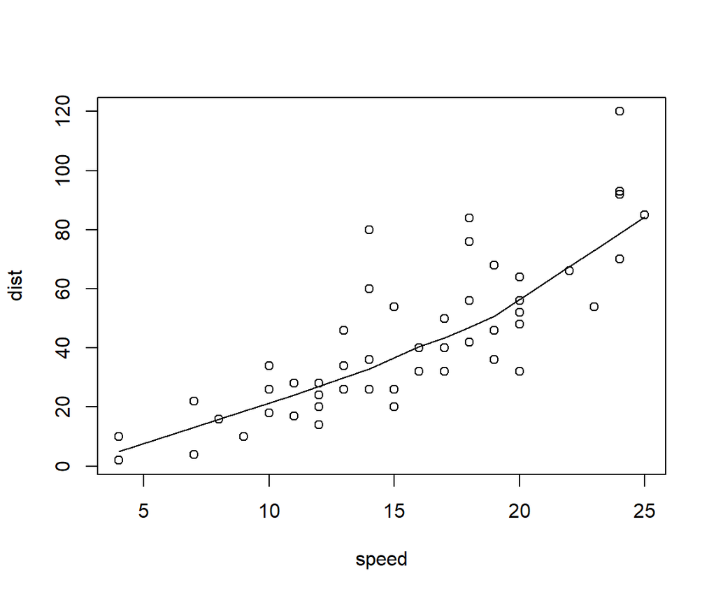

```r
require(stats) # dla lowess, rpois, rnorm
plot(cars)
lines(lowess(cars))
```

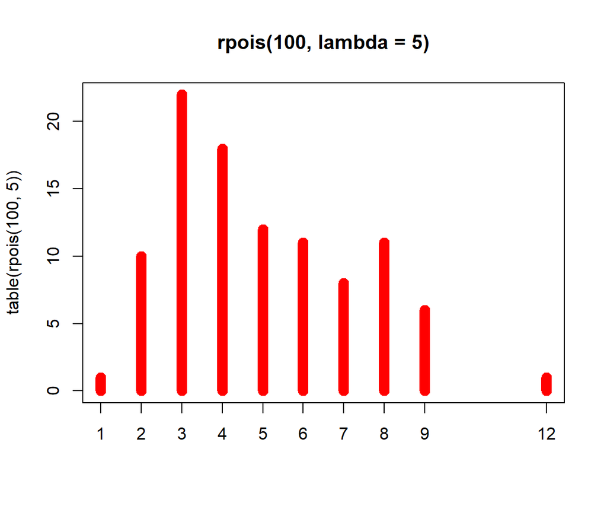

```r
plot(table(rpois(100, 5)), type = "h", col = "red", lwd = 10,
     main = "rpois(100, lambda = 5)") # wykres dla danych dyskretnych wygenerowanych losowo, rozkład Poisson'a
```

#### **Wykres słupkowy**

Służy głównie do przedstawiania danych kategorycznych

Formuła

```
barplot(height, ...)

Argumenty

height - wektor lub macierz opisująca słupki (wysokość)
width - opcjonalnie podawany wektor określający szerokość słupków
... - inne opcje wykresu
```

Przykłady

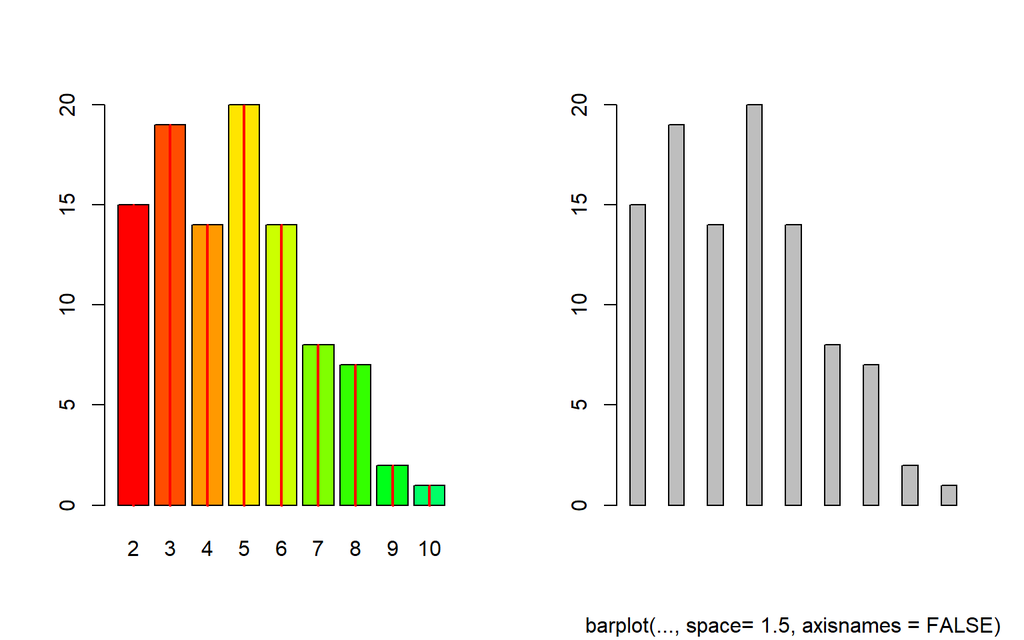

```r
par(mfrow = c(1,2))
require(grDevices) # kolory wykresu
tN <- table(Ni <- stats::rpois(100, lambda = 5))
r <- barplot(tN, col = rainbow(20))
lines(r, tN, type = "h", col = "red", lwd = 2) # type = "h" to wykres słupkowy

barplot(tN, space = 1.5, axisnames = FALSE,
        sub = "barplot(..., space= 1.5, axisnames = FALSE)")
```

```r
VADeaths # Liczba zgonóW w satnie Virginia w różnych kategoriach wiekowych
```

```
      Rural Male Rural Female Urban Male Urban Female
50-54       11.7          8.7       15.4          8.4
55-59       18.1         11.7       24.3         13.6
60-64       26.9         20.3       37.0         19.3
65-69       41.0         30.9       54.6         35.1
70-74       66.0         54.3       71.1         50.0
```

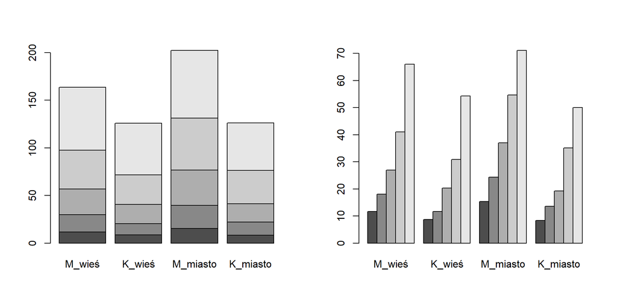

```r
par(mfrow = c(1,2))
barplot(VADeaths, names.arg = c("M_wieś", "K_wieś", "M_miasto", "K_miasto"))
barplot(VADeaths, beside = TRUE, names.arg = c("M_wieś", "K_wieś", "M_miasto", "K_miasto"))
```

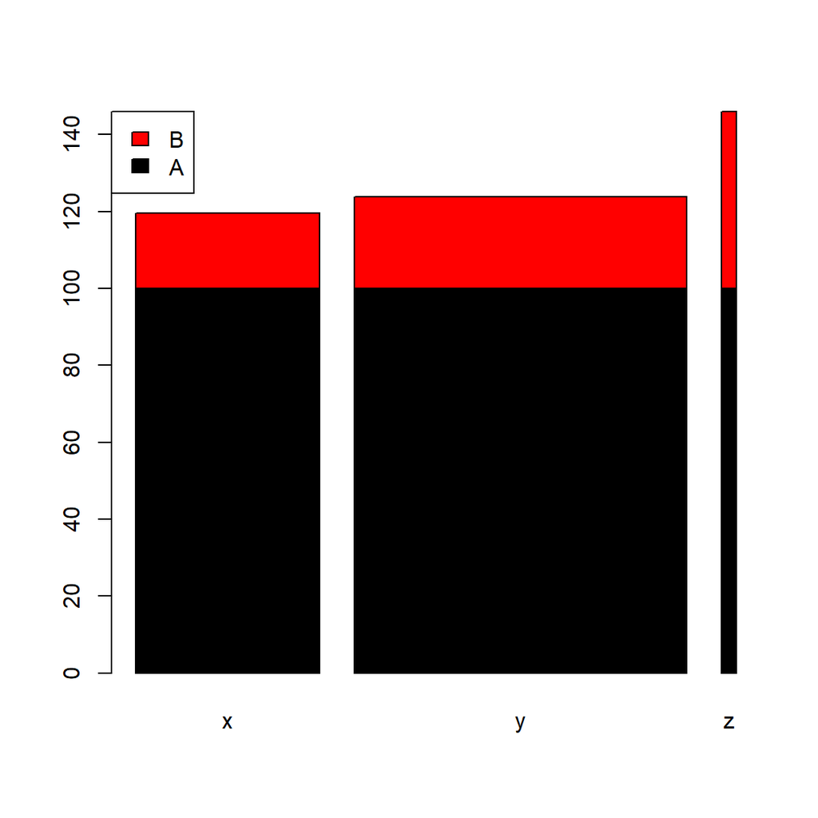

```r
# legenda
barplot(height = cbind(x = c(465, 91) / 465 * 100,
                       y = c(840, 200) / 840 * 100,
                       z = c(37, 17) / 37 * 100),
        beside = FALSE,
        width = c(465, 840, 37),
        col = c(1, 2),
        legend.text = c("A", "B"),
        args.legend = list(x = "topleft"))
```

#### **Wykres pudełkowy**

Służy do wizualizacji rozrzutu danych oraz jego porównywania między badanymi grupami

Formuła

```
boxplot(x, ...) # dla danych
boxplot(formula, data, ...) # dla formuły

Argumenty:
formula - formuła typu y ~ grp, gdzie y jest wektorem numerycznym powstałym przez grupowanie danych względem czynnika grupującego 'grp' (zwykle czynnika)
data - ramka danych lub lista, na której została zastosowana formuła
x - wektor liczbowy lub lista składająca się z wektorów, an podstawie, których ma być utworzony wykres
```

Przykłady

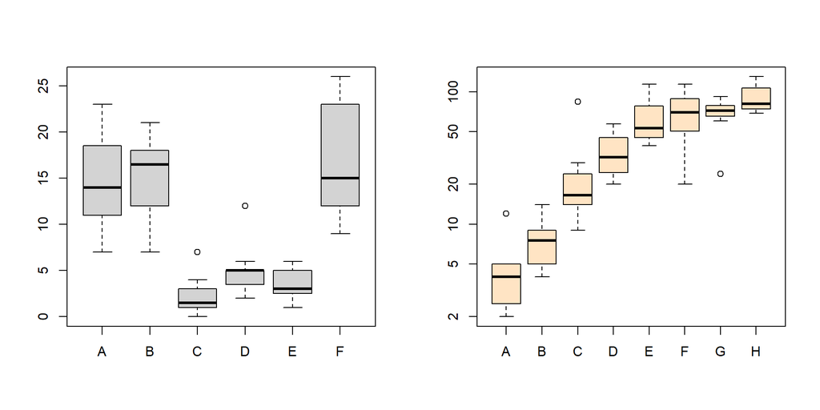

```r
par(mfrow = c(1,2))
boxplot(count ~ spray, data = InsectSprays, col = "lightgray") # wykorzystanie formuły
boxplot(decrease ~ treatment, data = OrchardSprays,
        log = "y", col = "bisque")
```

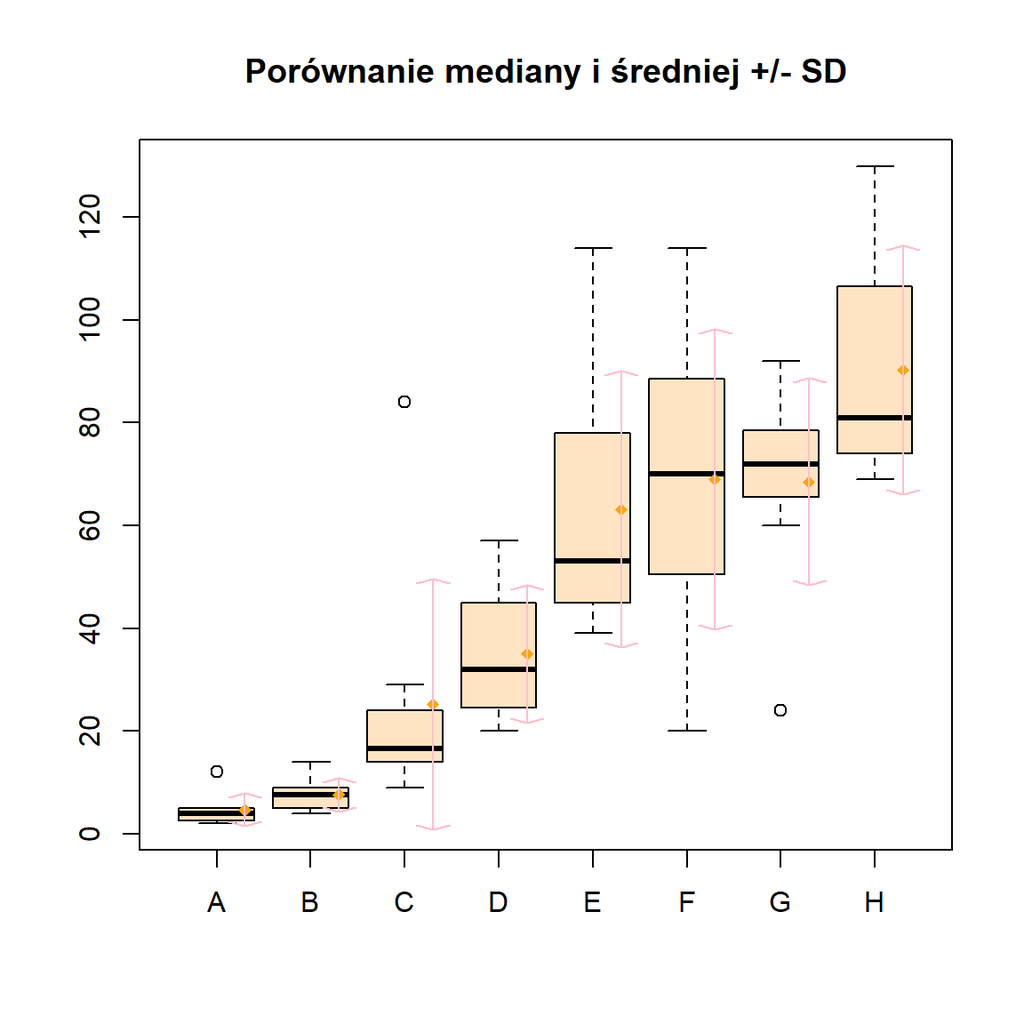

```r
rb <- boxplot(decrease ~ treatment, data = OrchardSprays, col = "bisque")
title("Porównanie mediany i średniej +/- SD")
mn.t <- tapply(OrchardSprays$decrease, OrchardSprays$treatment, mean)
sd.t <- tapply(OrchardSprays$decrease, OrchardSprays$treatment, sd)
xi <- 0.3 + seq(rb$n)
points(xi, mn.t, col = "orange", pch = 18)
arrows(xi, mn.t - sd.t, xi, mn.t + sd.t,
       code = 3, col = "pink", angle = 75, length = .1)
```

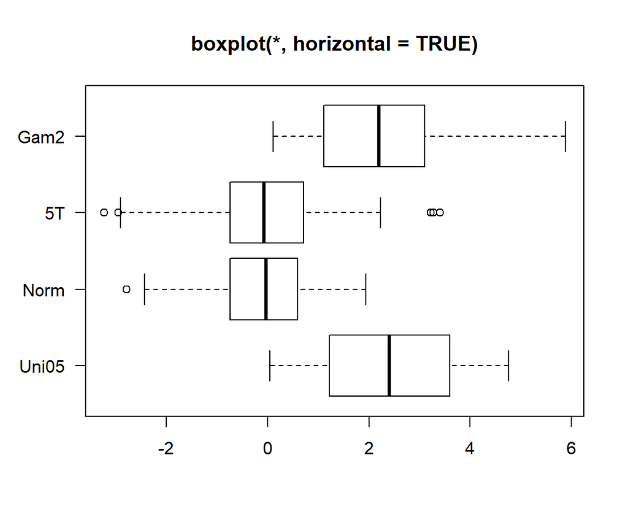

```r
mat <- cbind(Uni05 = (1:100)/21, Norm = rnorm(100),
             `5T` = rt(100, df = 5), Gam2 = rgamma(100, shape = 2))
df.mat <- as.data.frame(mat)
par(las = 1) # horyzontalne ustawienie etykiet
boxplot(df.mat, main = "boxplot(*, horizontal = TRUE)", horizontal = TRUE)
```

#### **1-wymiarowy wykres punktowy**

Przedstawia rozkład danych w postaci punktów i jest dobrą alternatywą dla wykresów pudełkowych, gdy dane są małoliczne

Formuła

```
stripchart(x, data, ...)

Argumenty:
x - dane liczbowe w postaci wektora lub listy wektorów liczbowych (każdy odpowiadający komponencie wykresu). Jeśłi używamy formuły y ~ g do grupowania danych
dane dzielone sa na poziomy odpowiadające poziomom 'g'
data - ramka danych lub lista, z której pobierane będa dane
... - inne parametry
```

Przykłady

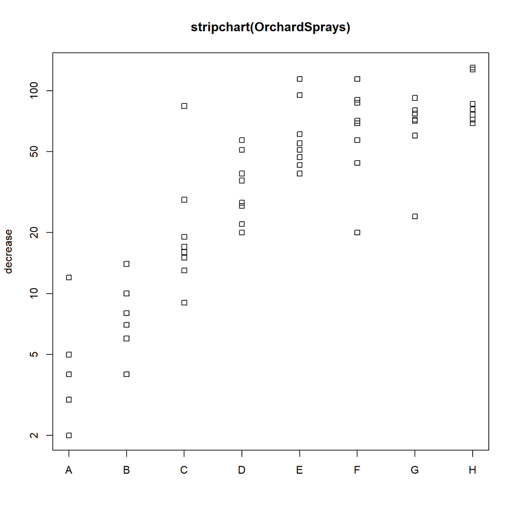

```r
stripchart(decrease ~ treatment,
    main = "stripchart(OrchardSprays)",
    vertical = TRUE, log = "y", data = OrchardSprays)
```

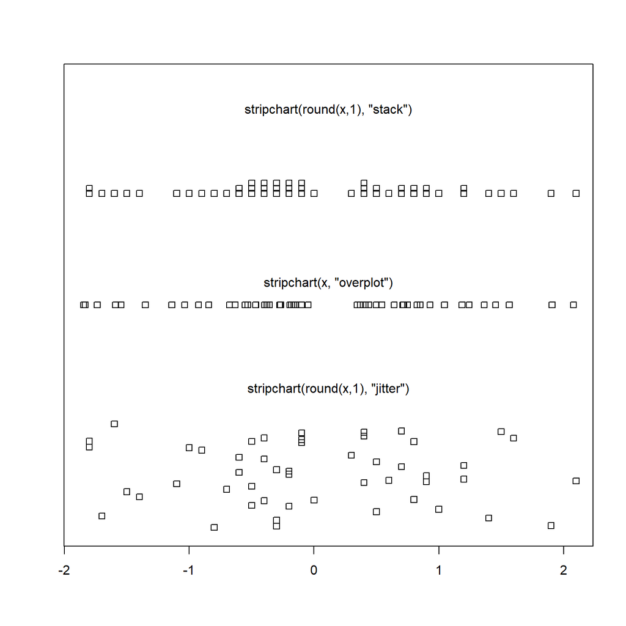

```r
x <- stats::rnorm(50) # dane losowe o rozkładzie normalnym
xr <- round(x, 1)
stripchart(x) ; m <- mean(par("usr")[1:2])
text(m, 1.04, "stripchart(x, \"overplot\")")
stripchart(xr, method = "stack", add = TRUE, at = 1.2)
text(m, 1.35, "stripchart(round(x,1), \"stack\")")
stripchart(xr, method = "jitter", add = TRUE, at = 0.7)
text(m, 0.85, "stripchart(round(x,1), \"jitter\")")
```

#### **Histogram**

Przedstawia liczebność danych podzielonych na zakresy

Formuła

```
hist(x, breaks, ...)

Argumenty:
x - wektor, na podstawie, którego budowany jest histogram
breaks - dane dotyczące podziału danych na zakresy (bins)
freq - jeśli TRUE, dane przedstawione są jako częstości, jeśli FALSE - wykreślana jest gęstość funkcji (wartość wszystkich elementów wykresu sumowana jest do 1)
```

Przykłady

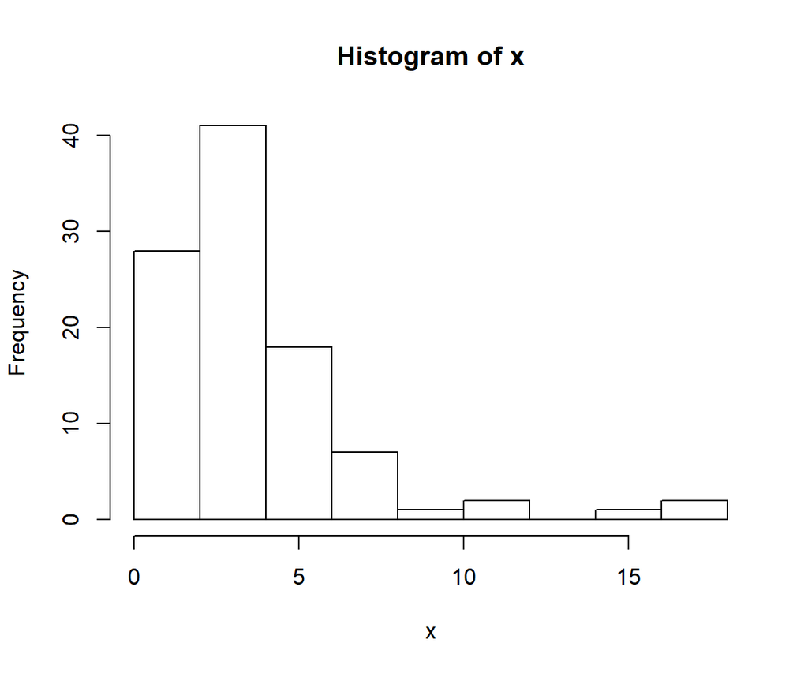

```r
require(stats)
set.seed(14)
x <- rchisq(100, df = 4) # losowe generowanie danych
hist(x)
```

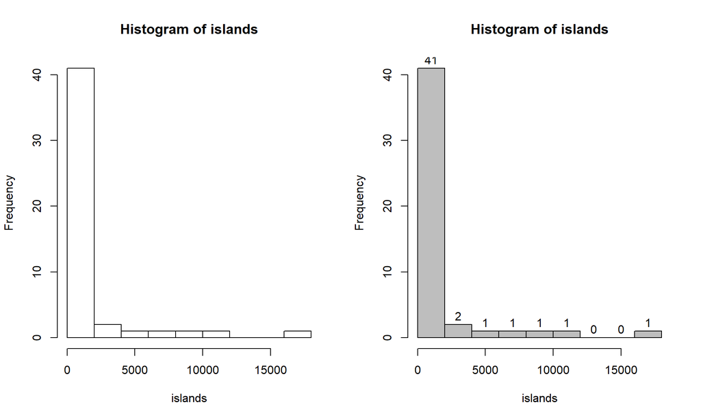

```
List of 6
 $ breaks  : num [1:10] 0 2000 4000 6000 8000 10000 12000 14000 16000 18000
 $ counts  : int [1:9] 41 2 1 1 1 1 0 0 1
 $ density : num [1:9] 4.27e-04 2.08e-05 1.04e-05 1.04e-05 1.04e-05 ...
 $ mids    : num [1:9] 1000 3000 5000 7000 9000 11000 13000 15000 17000
 $ xname   : chr "islands"
 $ equidist: logi TRUE
 - attr(*, "class")= chr "histogram"
```

```r
par(mfrow = c(1, 2))
hist(islands)
utils::str(hist(islands, col = "gray", labels = TRUE))
```

#### **Wykres mozaikowy**

Przedsatwia dane zebrane w tabeli krzyżowej

Formuła

```
mosaicplot(x, ...) # tabela danych
mosaicplot(formula, data, ...) # formula zależności danych

Argumenty:
x - tabela krzyżowa w formie macierzy
formula - formuła grupująca dane, które chcemy przedstawić na wykresie
```

Przykłady

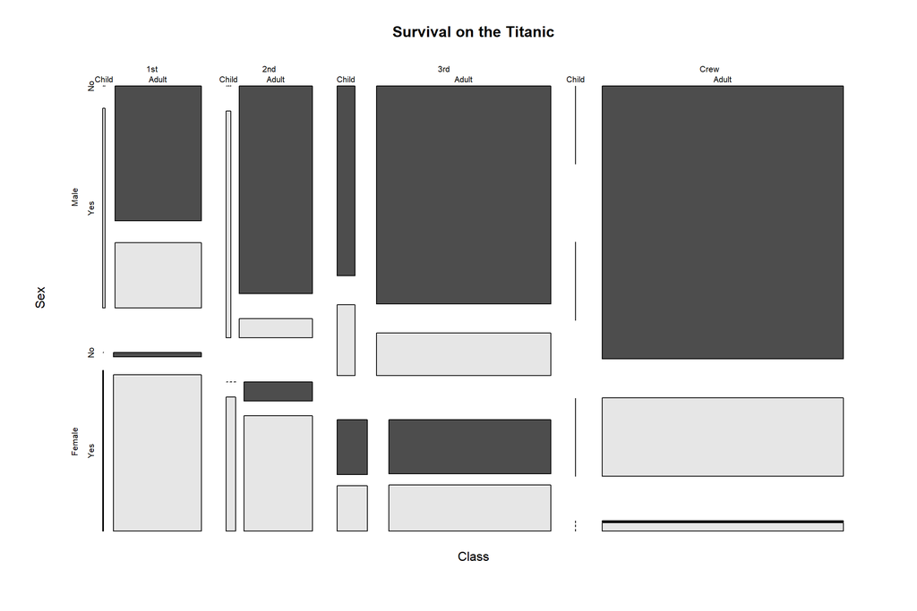

```r
require(stats)
mosaicplot(Titanic, main = "Survival on the Titanic", color = TRUE)
```

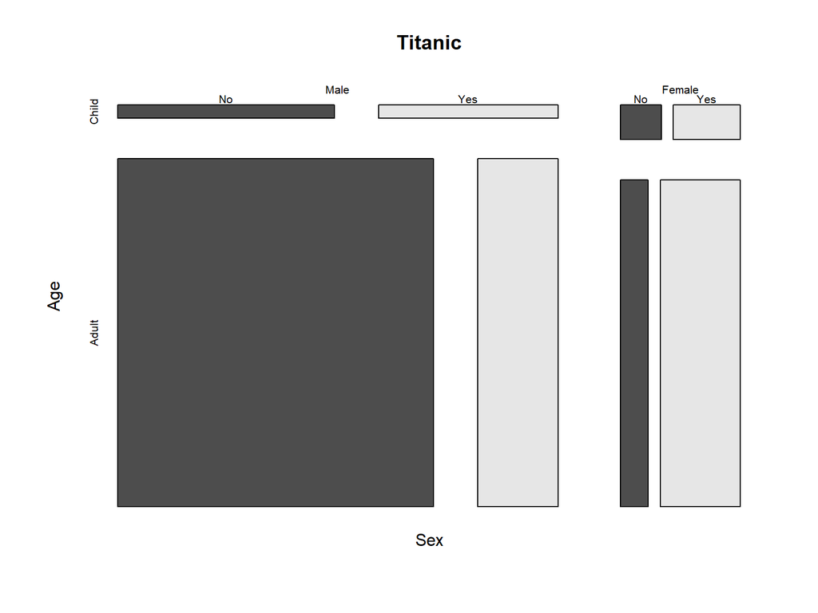

```r
require(stats)
mosaicplot(~ Sex + Age + Survived, data = Titanic, color = TRUE) # formuła dla danych stabelaryzowanych
```

### Podstawy programowania

**Pętla FOR**

for (`ZMIENNA` in `SEKWENCJA`){ `WYKONAJ` }

Przykład:

```r
for (i in 1:4){
j <- i + 10
print(j)
}
```

```
[1] 11
[1] 12
[1] 13
[1] 14
```

**Pętla WHILE**

while (`WARUNEK`){ `WYKONAJ` }

Przykład:

```r
i = 0
while (i < 5){
print(i)
i <- i + 1
}
```

```
[1] 0
[1] 1
[1] 2
[1] 3
[1] 4
```

```r
i
```

```
[1] 5
```

**Instrukcja warunkowa IF … ELSE …**

if (`WARUNEK`){ `WYKONAJ 1` } else { `WYKONAJ 2` }

Przykład:

```r
a <- c(2,4,7,1,1,3,5)

if (i > 3){
print("Yes")
} else {
print("No")
}
```

```
[1] "Yes"
```

```r
for (i in a){
if (i > 3){
print("Yes")
} else {
print("No")
}}
```

```
[1] "No"
[1] "Yes"
[1] "Yes"
[1] "No"
[1] "No"
[1] "No"
[1] "Yes"
```

```r
liczba <- 1233
if (liczba %% 2 == 0) {
  cat("liczba parzysta")
} else {
  cat("liczba nieparzysta")
}
```

```
liczba nieparzysta
```

```r
# Zagnieżdżenie funkcji

a <- c(6,8,12,7,3)
b <- c(11,4,7,9,7)
c <- c(6,9,67,8,9)
d <- data.frame(a,b,c)

for (i in 1:length(d)){
print(mean(d[,i]))
i <- i + 1}
```

```
[1] 7.2
[1] 7.6
[1] 19.8
```

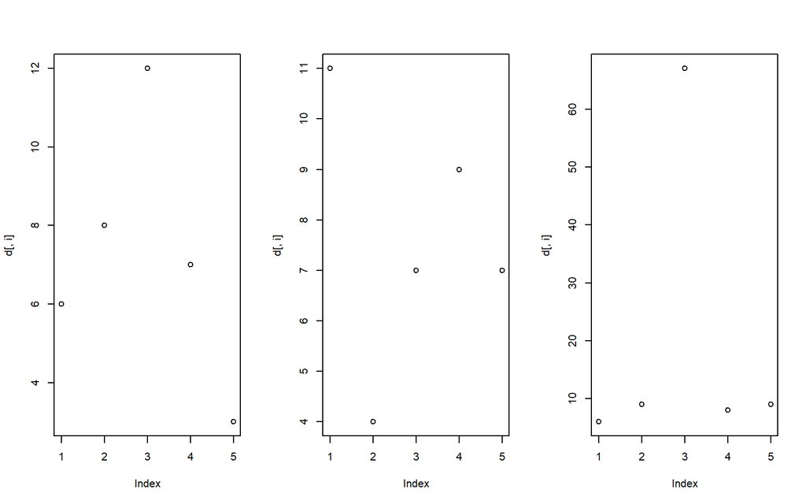

```r
par(mfrow = c(1,3))
for (i in 1:length(d)){
plot(d[,i])
i <- i + 1}
```

Do policznia średniej, czy też zastosowania innej funkcji na kolumnach lub wierszach ramki danych można wykorzystać wcześniej opisana funkcję `apply`

```r
apply(d,2,mean)
```

```
   a    b    c
 7.2  7.6 19.8
```

**Funkcje**

nazwa_funkcji <- function(`ZMIENNA`){ `WYKONAJ` return(`NOWA_ZMIENNA`) }

Przykład:

```r
square <- function(x){
squared <- x*x
return(squared)
}
square(5)
```

```
[1] 25
```

```r
square(c(2,3,8))
```

```
[1]  4  9 64
```